# Repeated heat exposure and susceptible coral composition

Implications of McWilliam et al. (2026) for the GBR mortality models

Published

August 24, 2026

## Decision summary

McWilliam et al. (2026) strengthens the case that present DHW is not enough. Two pre-event histories need to remain distinct:

1. **Years since the last >6-DHW event** represents the interval available for coral recovery and reassembly of susceptible taxa.
2. **Number of prior >6-DHW events since 2016** represents repeated exposure and selective loss of susceptible communities.

The pipeline previously had a leakage-safe years-since variable and a ten-year thermal-load summary, but it did not use an explicit fixed-origin event count. That count is now reconstructed for every operational reef feature. A rolling eight-year count is also retained as a future-facing sensitivity metric, but it should not enter the same small BRMS formula as the fixed count unless blocked validation shows that both add independent information.

The paper also shows that total *Acropora* is an incomplete susceptibility measure. Tabular and staghorn *Acropora* carry much of the signal. The local AIMS workspace only resolves the relevant field to total *Acropora*; it does not contain a tabular/staghorn split. Total *Acropora* remains the operational fallback, but the missing morphology layer is now explicit rather than hidden.

## What the paper shows

The 2024 response was shaped by ecological memory. Reefs with repeated severe heat exposure since 2016 often had depleted heat-sensitive taxa and lower 2024 bleaching or mortality. Reefs with a seven-to-eight-year recovery interval had rebuilt fast-growing branching and tabular *Acropora* and could suffer severe loss when exposed again. At a given DHW, high tabular/staghorn *Acropora* and low massive or branching *Porites* were associated with positive bleaching residuals.

This is best treated as a mechanism and prior expectation, not as a coefficient to copy directly. The paper’s intensive 2024 community analysis covers 23 reefs and immediate bleaching/mortality, whereas this pipeline predicts broader programme observations and annual cover change across multiple events.

## Leakage-safe exposure reconstruction

All history fields stop at 31 December of the year before the response. The current event’s DHW remains a separate predictor. This matters most for 2024: including the 2024 event in the event-frequency count would leak the response year’s thermal exposure into a variable described as ecological history.

The new fields are:

| Field | Definition | Default role |
| --- | --- | --- |
| `dhw_events_since2016_n6` | Count of annual maxima >6 DHW from 2016 through target year minus one | Primary repeated-exposure predictor |
| `dhw_years_since_last_n6` | Uncapped years since the last pre-event annual maximum >6 DHW | Audit and interpretation |
| `dhw_years_since_last_n6_capped8` | Years since last event, capped at eight; no previous event also maps to eight and is identified separately | Primary recovery-interval predictor |
| `dhw_no_prior_n6` | Censoring flag where no previous >6-DHW year exists | Keeps “no event observed” distinct from a long known interval |
| `dhw_events_prior8_n6` | Count in the preceding eight complete years | Operational sensitivity after the fixed 2016 origin ages |
| `dhw_history_years_since2016` | Number of observed historical years contributing to the fixed count | Provenance/coverage, not an ecological effect |

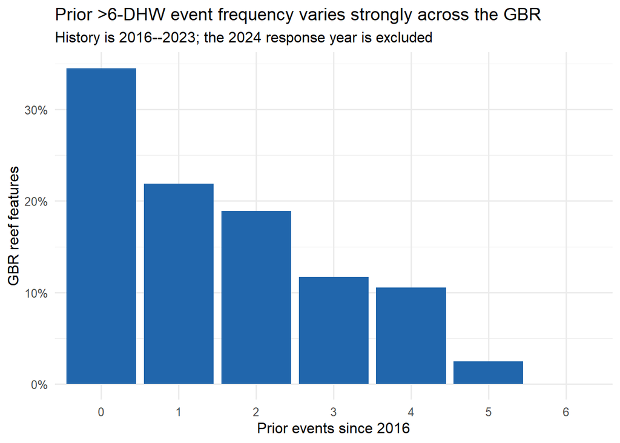

In 2024, 24.7% of operational reef features had at least three prior >6-DHW years, while 34.5% had none.

Exposure history at reefs under review

| Reef | DHW_2024 | Prior events since 2016 | Years since last >6 DHW | No prior >6 DHW |
| --- | --- | --- | --- | --- |
| Eyrie Reef (14-118) | 6.27 | 2 | 7 | FALSE |
| Linnet Reef (14-126) | 6.73 | 2 | 7 | FALSE |
| Lizard Island Reef (Coconut Bay) (14-116c) | 5.93 | 2 | 7 | FALSE |
| Lizard Island Reef (Lagoon) (14-116d) | 6.27 | 2 | 7 | FALSE |
| Lizard Island Reef (North East) (14-116b) | 5.93 | 2 | 7 | FALSE |
| Lizard Island Reef (North West) (14-116a) | 6.27 | 2 | 7 | FALSE |
| Mackay Reef (16-015) | 3.52 | 1 | 7 | FALSE |
| Mackay Reefs (15-024) | 4.58 | 2 | 7 | FALSE |
| Swinger Reef (15-030) | 3.87 | 1 | 7 | FALSE |

## Composition resolution

Resolution available in the local AIMS community workspace

| composition_field | available | rows | reefs | first_year | last_year | source_categories | source_variables |
| --- | --- | --- | --- | --- | --- | --- | --- |
| Total Acropora | TRUE | 2676 | 120 | 1992 | 2025 | Acropora | HARD CORAL |
| Tabular Acropora | FALSE | 0 | 0 | NA | NA | NA | NA |
| Staghorn Acropora | FALSE | 0 | 0 | NA | NA | NA | NA |
| Branching Acropora | FALSE | 0 | 0 | NA | NA | NA | NA |

The audit finds total *Acropora* observations but no category or source variable identifying tabular, staghorn or branching *Acropora*. Those values must come from a more resolved image/transect product or a separately validated community model. They must not be inferred by setting a fixed fraction of total *Acropora* or by filling missing values with zero.

For operational GBR-wide predictions, the staged composition contract is:

- retain past-only total *Acropora* and total coral cover everywhere;
- add observed tabular/staghorn cover when a taxonomically resolved source is recovered;
- if a GBR-wide morphology model is later built, carry its prediction and uncertainty separately from observed composition; and
- report performance for observed-morphology and imputed-morphology subsets.

## Model comparison to run next

The paper implies both direct history and composition-mediated pathways. The next blocked comparison should therefore be deliberately small:

1. current production history (`yrsince6`, chronic load and novelty);
2. add prior event count plus its DHW interaction;
3. add total *Acropora* plus DHW–*Acropora* interaction;
4. add tabular/staghorn *Acropora* only when a defensible source exists.

BRMS should prespecify the DHW interactions and use regularising priors; BRT can learn the corresponding nonlinear interactions. Evaluation must retain leave-one-event-out, unseen-reef and reef-blocked-2024 views, with severe-case bias and calibration alongside RMSE, MAE, predictive R2 and information criteria for comparable likelihood models.

The key diagnostic is whether repeated exposure reduces predicted response at a fixed DHW because susceptible communities have been filtered, while a long recovery interval and high susceptible composition increase it. If the history effect disappears after resolved composition is added, that is scientifically informative mediation rather than a failed predictor.